# chi square

Muturi

2024-04-02

### Chi square test for indepedence

Suppose in our ideal1 dataset we wanted to establish if mortality differed by calf sex

```r
## Calf sex
ideal1a <- ideal1
## recode variables
ideal1a$CalfSex <- ifelse(ideal1a$CalfSex=="1","male","female")
ideal1a$ReasonsLoss <- ifelse(is.na(ideal1a$ReasonsLoss),"survived","died")
## tabulate mortality by sex
table(ideal1a$CalfSex,ideal1a$ReasonsLoss)
```

```
##
##          died survived
##   female    1        9
##   male      8       12
```

Are mortality and calf sex independent?

```r
chisq.test(ideal1a$CalfSex,ideal1a$ReasonsLoss)
```

```
##
##  Pearson's Chi-squared test with Yates' continuity correction
##
## data:  ideal1a$CalfSex and ideal1a$ReasonsLoss
## X-squared = 1.6071, df = 1, p-value = 0.2049
```

assumptions for chisquare statistical test: 1.The data are obtained from a random sample. 2.The expected value in each must be 5 or more.If the expected are not 5 or more ,compibine categories or use fischer formular.

In this case, we had a category with 1 variable and that prompts us to use fischer method.

```r
## conduct a Fisher's exact test
fisher.test(ideal1a$CalfSex,ideal1a$ReasonsLoss)
```

```
##
##  Fisher's Exact Test for Count Data
##
## data:  ideal1a$CalfSex and ideal1a$ReasonsLoss
## p-value = 0.2035
## alternative hypothesis: true odds ratio is not equal to 1
## 95 percent confidence interval:
##  0.003392504 1.738887784
## sample estimates:
## odds ratio
##   0.175527
```

Results: Based on this Fisher’s Exact Test, there is not enough evidence to suggest that calf death is significantly determined by calf sex.

## CHI Square test for goodness of fit

The students data set consists of 8239 rows, each of them representing a particular student, and 16 columns, each of them corresponding to a variable/feature related to that particular student. These self-explaining variables are: stud.id, name, gender, age, height, weight, religion, nc.score, semester, major, minor, score1, score2, online.tutorial, graduated, salary.In order to showcase the χ2 goodness-of-fit test we examine, if religions are equally distributed among students compared to the distribution of religions among the population of the European Union(lets call it census in kenyan context).The report provides data for 8 categories: 48 % of the people are ascribed as Catholic, 16 % as Non believer/Agnostic, 12 % as Protestant, 8% as Orthodox, 7% as Atheist, 4 % as Other Christian, 3 % as Other religion/None stated and 2 % as Muslim

```r
library(tidyverse)
students <- read_csv("students.csv")
```

lets visualize the report results

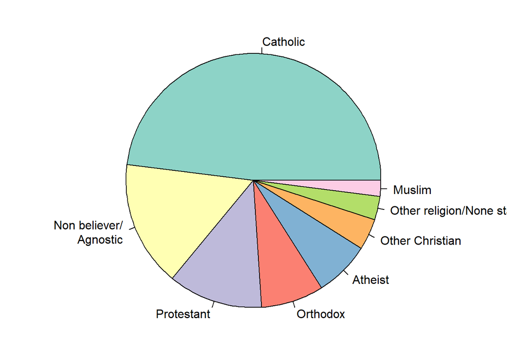

```r
data <- c(48, 16, 12, 8, 7, 4, 3, 2)
data_labels <- c(
  "Catholic", "Non believer/\nAgnostic", "Protestant",
  "Orthodox", "Atheist", "Other Christian",
  "Other religion/None stated", "Muslim"
)

par(mar = c(3, 2, 3, 2))
library(RColorBrewer)
cols <- brewer.pal(length(data), "Set3")

pie(
  x = data,
  labels = data_labels,
  col = cols,
  radius = 1
)
```

Data preparation: First, we want to know which categories are available in the students data set. Therefore, we apply the unique() function, which provides access to the levels (categories) of a variable.

```r
unique(students$religion)
```

[output not shown]

[output cut: 24 more lines]

```r
# set category names
data_labels <- c("Catholic", "Muslim", "Orthodox", "Other", "Protestant")

# recode European data according to category names-This line creates a vector data_raw containing the counts of each religious category. However, for the "Other" category, instead of providing a single count, it's using the sum() function to sum up counts of subcategories (16, 7, 4, and 3) within the "Other" category.
data_raw <- c(48, 2, 8, sum(16, 7, 4, 3), 12)

# generate a data.frame object-Here, you're creating a data frame data from the relative frequencies. Since the data_raw vector contains counts, dividing it by 100 converts it into relative frequencies. Then, you assign row names using data_labels and column name as "relative_frequency"
data <- data.frame(data_raw / 100)
row.names(data) <- data_labels
colnames(data) <- "relative_frequency"
data
```

```
##            relative_frequency
## Catholic                 0.48
## Muslim                   0.02
## Orthodox                 0.08
## Other                    0.30
## Protestant               0.12
```

```r
n <- 256
students_sample <- sample(students$religion, n)
O_frequencies <- table(students_sample)
O_frequencies
```

[output not shown]

```r
tryCatch({
  data$observed_frequencies <- O_frequencies
  data
}, error = function(e) {
  message("table 5*3: ", e$message)
})
```

[output not shown]

n the next step we calculate the expected frequencies. Recall the equation:

E=n×p

We insert the expected frequencies as a new column in data.

```r
n <- 256
data$expected_frequencies <- n * data$relative_frequency
data
```

```
##            relative_frequency expected_frequencies
## Catholic                 0.48               122.88
## Muslim                   0.02                 5.12
## Orthodox                 0.08                20.48
## Other                    0.30                76.80
## Protestant               0.12                30.72
```

Hypothesis testing ie Is the religion equally distributed among students compared to the distribution of the religion among the population of the European Union?

```r
tryCatch({
  chisq.test(data$observed_frequencies, p = data$relative_frequency)
}, error = function(e) {
  message("X-squared = 69.475, df = 4, p-value = 2.929e-14
: ", e$message)
})
```

[output not shown]